# Initiation à la programmation orientée objet

Lire [POO](https://fr.wikipedia.org/wiki/Programmation_orient%C3%A9e_objet) et tvaira.free.fr

## Notion d’objets

La programmation orientée objet consiste à **définir des objets logiciels et à les faire interagir entre eux**.

Concrètement, un **objet** est une *structure de données* (*ses attributs* c.-à-d. des *variables*) qui définit son *état* et une *interface* (*ses méthodes* c.-à-d. des *fonctions*) qui définit son *comportement*.

Un objet est créé à partir d’un *modèle* appelé **classe**. Chaque objet créé à partir de cette classe est une **instance** de la classe en question.

## Notion de classe

Une classe **déclare des propriétés communes** à un ensemble d’objets.

Une classe représentera donc une *catégorie d’objets*.

Elle apparaît comme un **type** ou un *moule* à partir duquel il sera possible de *créer des objets*.

## Notion de visibilité

Le C++ permet de préciser le **type d’accès des membres** (*attributs* et *méthodes*) d’un objet :

- `public` : les membres publics peuvent être utilisés dans et par n’importe quelle partie du programme.
- privé (`private`) : les membres privés d’une classe ne sont accessibles que par les objets de cette classe et non par ceux d’une autre classe.

Cette opération s’effectue **au sein des classes**[^1].

## Notion d’encapsulation

L’encapsulation est l’idée de **protéger les variables contenues dans un objet et de ne proposer que des méthodes pour les manipuler**.

En respectant ce principe, toutes les variables (*attributs*) d’une classe seront donc **privées** (`private`).

L’objet est ainsi vu de l’extérieur comme une `boîte noire` possédant certaines propriétés et ayant un comportement spécifié.

# Exemple détaillé : une classe `Point`

Nous allons successivement découvrir les notions suivantes :

1. la modélisation et la déclaration d’une classe
2. la construction d’objets d’une classe et la définition de ses fonctions membres
3. les services rendus par une classe
4. l’accès contrôlé aux membres d’une classe

Voir http://tvaira.free.fr

## Modélisation d’une classe

On veut manipuler des **points**. Un *point* est défini par **son** abscisse (`x`) et **son** ordonnée (`y`). L’abscisse et l’ordonnée d’un point sont des **réels** (`double`).

On en sait suffisamment pour modéliser une **classe `Point`** :

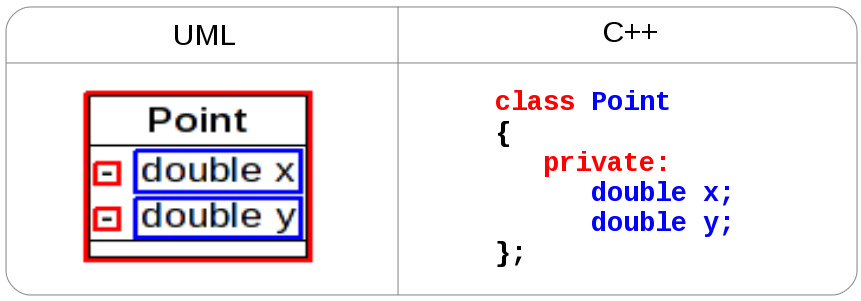

Modélisation d’une **classe `Point`**

Le code C++ ci-dessus correspond à la **déclaration de la classe `Point`**. Elle se placera donc dans un fichier en-tête (*header*) `Point.h`.

## Construction d’objets

Pour **créer des objets**, il faudra … **un constructeur** :

- Un constructeur est chargé d’**initialiser un objet de la classe**.
- Il est appelé **automatiquement au moment de la création** de l’objet.
- Un constructeur est une méthode qui porte toujours le même nom que la classe.

> Il existe quelques contraintes :
> - Il peut avoir des paramètres, et des valeurs par défaut.
> - Il peut y avoir plusieurs constructeurs pour une même classe.
> - Il n’a jamais de type de retour.

On le **déclare** de la manière suivante :

```cpp
class Point
{
   private:
      double x, y; // nous sommes des attributs de la classe Point

   public:
      Point(double x, double y); // je suis le constructeur de la classe Point
};
```

Il faut maintenant **définir** ce constructeur afin qu’il *initialise tous les attributs de l’objet au moment de sa création* :

```cpp
// Je suis le constructeur de la classe Point
Point::Point(double x, double y)
{
   // je dois initialiser TOUS les attributs de la classe
   this->x = x; // on affecte l'argument x à l'attribut x
   this->y = y; // on affecte l'argument y à l'attribut y
}
```

On pourra alors **créer nos propres *objets* points** :

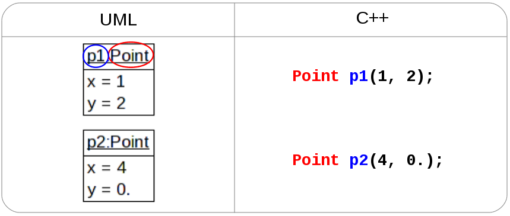

Les objets `p1` et `p2` sont des *instances* de la classe `Point`

Un objet possède sa **propre existence** et un *état* qui lui est spécifique (c.-à-d. les valeurs de ses attributs) :

| Point | x | y |
| --- | --- | --- |
| p1 | 1 | 2 |
| p2 | 4 | 0 |

# Définitions

**POO**

Programmation Orienté Objet

Retour au sommaire

[^1]: il existe aussi une visibilité dite protégée (`protected`)